# ISA 365 Exam 1 Output Packet

Last complied on September 30, 2025

### Amazon Tests

Amazon ran a price styling experiment. Notice they increased the font size and coloring of the pricing. The experiment ran on multiple product pages. Amazon measured the click through rate on the add to cart button (click the add to cart button or not).

#### Preliminaries

First the Analysts at Amazon completed a preliminary sample size study. They were interested in finding a difference in click through rates of 5%. Their current click through rate is 3.45%

```r
power.t.test(n=NULL, sig.level = 0.05, power=0.8, delta = 0.05)
```

```
##
##      Two-sample t test power calculation
##
##               n = 6280.064
##           delta = 0.05
##              sd = 1
##       sig.level = 0.05
##           power = 0.8
##     alternative = two.sided
##
## NOTE: n is number in *each* group
```

```r
power.prop.test(n=NULL, sig.level = 0.05, power=0.8, p1=0.0345, p2=0.036225)
```

```
##
##      Two-sample comparison of proportions power calculation
##
##               n = 179954.9
##              p1 = 0.0345
##              p2 = 0.036225
##       sig.level = 0.05
##           power = 0.8
##     alternative = two.sided
##
## NOTE: n is number in *each* group
```

[figure not shown]

A

[figure not shown]

B

#### Summary

```r
head(df)
```

[output not shown]

```r
df %>% group_by(variant) %>% summarise("mean"=mean(click), "sd"=sd(click), "count"=n())
```

```
## # A tibble: 2 × 4
##   variant   mean    sd count
##   <chr>    <dbl> <dbl> <int>
## 1 a       0.0329 0.178  5014
## 2 b       0.0215 0.145  5014
```

```r
df %>% group_by(variant, click) %>%  summarise(n = n()) %>%
  mutate(freq = n / sum(n))
```

```
## # A tibble: 4 × 4
## # Groups:   variant [2]
##   variant click     n   freq
##   <chr>   <int> <int>  <dbl>
## 1 a           0  4849 0.967
## 2 a           1   165 0.0329
## 3 b           0  4906 0.978
## 4 b           1   108 0.0215
```

#### Analysis

```r
t.test(df$click~df$variant)
```

```
##
##  Welch Two Sample t-test
##
## data:  df$click by df$variant
## t = 3.4995, df = 9628.5, p-value = 0.0004682
## alternative hypothesis: true difference in means between group a and group b is not equal to 0
## 95 percent confidence interval:
##  0.005000443 0.017735895
## sample estimates:
## mean in group a mean in group b
##      0.03290786      0.02153969
```

```r
prop.test(x=c(165, 108), n=c(5014,5014))
```

```
##
##  2-sample test for equality of proportions with continuity correction
##
## data:  c(165, 108) out of c(5014, 5014)
## X-squared = 11.809, df = 1, p-value = 0.0005896
## alternative hypothesis: two.sided
## 95 percent confidence interval:
##  0.004802437 0.017933902
## sample estimates:
##     prop 1     prop 2
## 0.03290786 0.02153969
```

### Etsy Button Color Test

Etsy ran this simple button experiment in February 2025 on their product page where they challenged their existing black add-to-cart button against a yellow button. Etsy measured the sales over a certain time period to determine if the color change helped.

[figure not shown]

A

[figure not shown]

B

#### Summary

```r
head(df)
```

```
##   visit_id user_spend variant
## 1    44222          0       A
## 2    59016          0       A
## 3    74729          0       A
## 4    96396          0       A
## 5    11771          0       A
## 6    33865          0       A
```

```
## # A tibble: 2 × 4
##   variant  mean    sd count
##   <chr>   <dbl> <dbl> <int>
## 1 A        4.61  15.2  3401
## 2 B        5.89  18.3  3426
```

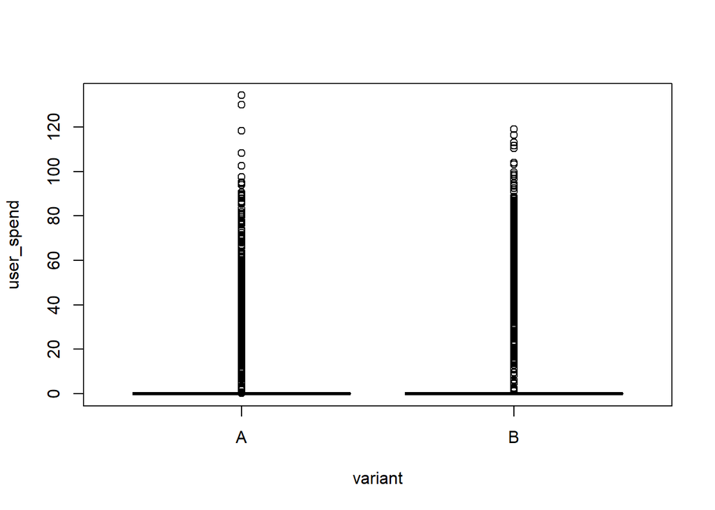

```r
boxplot(user_spend~variant, data=df)
```

#### Analysis 1

```r
t.test(user_spend~variant, data=df)
```

```
##
##  Welch Two Sample t-test
##
## data:  user_spend by variant
## t = -3.1353, df = 6618.9, p-value = 0.001724
## alternative hypothesis: true difference in means between group A and group B is not equal to 0
## 95 percent confidence interval:
##  -2.0748544 -0.4784323
## sample estimates:
## mean in group A mean in group B
##        4.614099        5.890743
```

For variant B:

```r
dfB<-df %>% filter(variant=="B")
mean(dfB$user_spend)
```

```
## [1] 5.890743
```

```r
sd(dfB$user_spend)
```

```
## [1] 18.30756
```

For variant B:

```r
5.890743+qnorm(0.975)+18.30756/sqrt(3426)
```

```
## [1] 8.163485
```

```r
5.890743 -qnorm(0.975)+18.30756/sqrt(3426)
```

```
## [1] 4.243557
```

For variant B:

```r
5.890743 +qnorm(0.95)+18.30756/sqrt(3426)
```

```
## [1] 7.848375
```

```r
5.890743-qnorm(0.95)+18.30756/sqrt(3426)
```

```
## [1] 4.558668
```

For variant B:

```r
5.890743 +qt(0.975, 3425)+18.30756/sqrt(3426)
```

```
## [1] 8.164178
```

```r
5.890743-qt(0.975, 3425)+18.30756/sqrt(3426)
```

```
## [1] 4.242865
```

For variant B:

```r
5.890743+qt(0.95, 3425)+18.30756/sqrt(3426)
```

```
## [1] 7.84882
```

```r
5.890743-qt(0.95, 3425)+18.30756/sqrt(3426)
```

```
## [1] 4.558223
```

#### Analysis 2

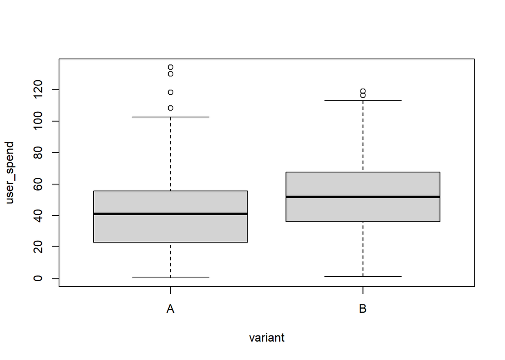

```r
sub<-df %>% filter(user_spend>0)
boxplot(user_spend~variant, data=sub)
```

```r
sub %>% group_by(variant) %>% summarize("mean"=mean(user_spend), "sd"=sd(user_spend), "count"=n())
```

```
## # A tibble: 2 × 4
##   variant  mean    sd count
##   <chr>   <dbl> <dbl> <int>
## 1 A        41.7  23.3   376
## 2 B        52.3  23.4   386
```

```r
t.test(user_spend~variant, data=sub)
```

```
##
##  Welch Two Sample t-test
##
## data:  user_spend by variant
## t = -6.2301, df = 759.71, p-value = 7.717e-10
## alternative hypothesis: true difference in means between group A and group B is not equal to 0
## 95 percent confidence interval:
##  -13.872498  -7.224794
## sample estimates:
## mean in group A mean in group B
##        41.73551        52.28416
```

### Airbnb Test

Airbnb tested the idea of surfacing the next available dates near their calendar picker (see version b). They measured if the property was booked or not.

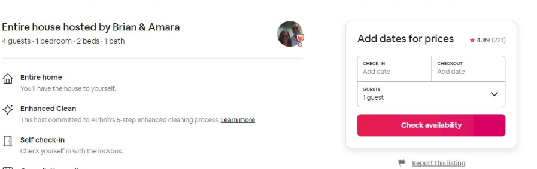

A

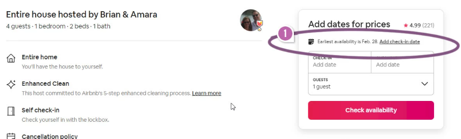

B

#### Summary

```r
head(df)
```

```
##   variant click
## 1       a     0
## 2       a     0
## 3       a     0
## 4       a     0
## 5       a     0
## 6       a     0
```

```
## # A tibble: 4 × 4
## # Groups:   variant [2]
##   variant click     n   freq
##   <chr>   <int> <int>  <dbl>
## 1 a           0  1217 0.969
## 2 a           1    39 0.0311
## 3 b           0  1350 0.974
## 4 b           1    36 0.0260
```

#### Analysis

```r
iter=100000
a=39+1
b=1217+1
a1=36+1
b1=1350+1
count<-c()
for (i in 1:iter){
A<-rbeta(1, a, b)
B<-rbeta(1, a1, b1)
count[i]<-ifelse(A>B, 1, 0)


}
pdiff<-sum(count)/iter
pdiff
```

```
## [1] 0.78395
```

```r
prop.test(x=c(39, 36), n=c( 1217 +39, 1350+36))
```

```
##
##  2-sample test for equality of proportions with continuity correction
##
## data:  c(39, 36) out of c(1217 + 39, 1350 + 36)
## X-squared = 0.44543, df = 1, p-value = 0.5045
## alternative hypothesis: two.sided
## 95 percent confidence interval:
##  -0.008415338  0.018569197
## sample estimates:
##     prop 1     prop 2
## 0.03105096 0.02597403
```

Individual intervals for variant A.

```r
a=39+1
b=1217+1
qbeta(0.975, a, b)
```

```
## [1] 0.04217153
```

```r
qbeta(0.025, a, b)
```

```
## [1] 0.02282927
```

```r
prop.test(x=39, n=1217)
```

```
##
##  1-sample proportions test with continuity correction
##
## data:  39 out of 1217, null probability 0.5
## X-squared = 1064.1, df = 1, p-value < 2.2e-16
## alternative hypothesis: true p is not equal to 0.5
## 95 percent confidence interval:
##  0.02318092 0.04397676
## sample estimates:
##          p
## 0.03204601
```

### High Speed Bike Helmet Effectiveness Study

A standard helmet (Control group)

A newly designed impact-resistant helmet (Treatment group)

To maintain the integrity of the study, both groups wore helmets that appeared identical from the outside. The 30 trial observers were also blinded to which helmets were the high-tech versions. Each student rode a controlled downhill course at a high speed and was instructed to navigate a difficult turn known to cause crashes. The primary outcome was whether the student sustained a serious head injury (binary response: 1 = Injury, 0 = No Injury). Note this is just a hypothetical study :).

| Name |
| --- |
| Anderson, Will |
| Archer, Nick |
| Banks, Madison |
| Cannon, Kim |
| DeFazio, Mia |
| Fuenfer, Braeden |

```r
set.seed(2025)
study<-df[1:20,] #first 20 rows in the data frame
```

| Name |
| --- |
| Anderson, Will |
| Archer, Nick |
| Banks, Madison |
| Cannon, Kim |
| DeFazio, Mia |
| Fuenfer, Braeden |
| Gall, Boden |
| Gigantelli, Elina |
| Gualtieri, Lauren |
| Harmon, Sydney |
| Huhn, Cameron |
| Lamanna, Kathleen |
| Leatherman, Madeline |
| Miller, Drew |
| Morrison, Lydia |
| Neu, Logan |
| Ona Jauregui, Felipe |
| Schneeberger, Matthew |
| Shroder, Andrew |
| Southworth, Paige |

#### Random Assignment

```r
treatment<-c(rep("new helmet",10), rep("old helmet",10))
treatment<-sample(treatment)
experiment<-data.frame(study, treatment)
```

| Name | treatment |
| --- | --- |
| Anderson, Will | old helmet |
| Archer, Nick | old helmet |
| Banks, Madison | new helmet |
| Cannon, Kim | new helmet |
| DeFazio, Mia | new helmet |
| Fuenfer, Braeden | old helmet |
| Gall, Boden | old helmet |
| Gigantelli, Elina | new helmet |
| Gualtieri, Lauren | old helmet |
| Harmon, Sydney | old helmet |
| Huhn, Cameron | old helmet |
| Lamanna, Kathleen | new helmet |
| Leatherman, Madeline | old helmet |
| Miller, Drew | new helmet |
| Morrison, Lydia | new helmet |
| Neu, Logan | new helmet |
| Ona Jauregui, Felipe | old helmet |
| Schneeberger, Matthew | new helmet |
| Shroder, Andrew | old helmet |
| Southworth, Paige | new helmet |